# readme

## Short description and considerations on developed plots

### Snake and Ladder” Plots

For a sequence of recorded calls, binned into a grid of cells/rectangles expressing calls of a given Duration interval (secs) and a given interval of values acoustic (e.g. Voice Entropy), these plots intend to describe the movement in the acoustic space of consecutive calls.

#### Directional Spokes

- This type of plot use arrows to describe the direction of subsequent calls in the acoustic space - i.e. an arrow represents a call and the direction of the cell containing the subsequent call.
- Comments:
  - The colour of the arrows map the nr. of occurrences in the given direction, conveying a sense of traffic intensity (i.e. darker shades indicate larger number of transitions in the same direction).
  - As seen on the exploratory analysis, Alex’s calls on both sessions were much shorter in duration than Riet’s calls. This causes Ale’s features to get squeezed up on the x-axis when the two subjects are plotted together or their individual plots are forced to use the same x-scale. So, while fixing the scale of x at the subject-level plots, session-level plots use varying x-scales (i.e scale based on inherent data) to get more detail of the movements occurring in each session.

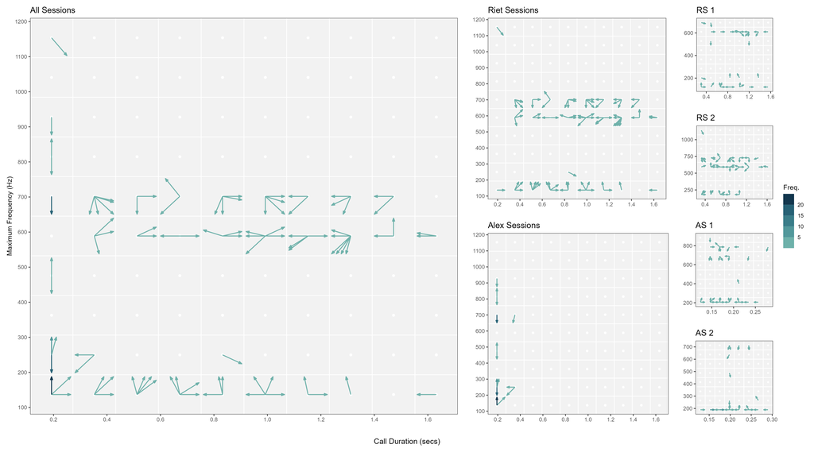

#### Directional Tracks

- These plots show the actual connections between each cells and subsequent cell. To help vizualization, arrows are colored to represent the direction of movement (in degrees), with the discrete color scale encoding the main cardinal directions (i.e. E, NE, N, NW, W, SW, S, SE).
- Comments:
  - Not sure how readable and interpretable these plots are - on first look they look a lot like toddler scribblings! :)
  - However, they do provide more detailed information than the directional spoke plots.
  - Ideally it would be cool to have a cyclical, compass-like, colour-guide instead of a colourbar-guide. However, implementing it in `ggplot` as been more challenging than initially thought. One additional downside to the compass-like guide is the plotting space required for it, which would mess up the current spacial arrangement of the panels.

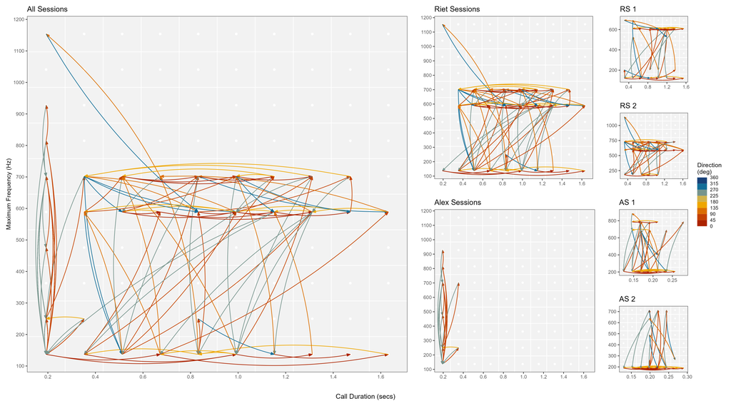

### “Pizza” plots

Intended to convey change in acoustic features of consecutive calls. For a given sequence of calls, points expressing acoustic changes between consecutive calls are graphically grouped into 8 slice-shaped radial polygons with origin at 0 (expressing no change). Furthermore:

- The length of each slice is given by the comprised point at furthest distance from origin.
- For a given the 2D spread of a set of points, diagonal slices illustrate cases where changes occurred predominately on both dimensions. Vertical and horizontal slices represent instances were changes were mostly uni-dimensional.
- Solid and dashed lines express, respectively, the median and percentiles (2.5% and 97.5%) of the distances between the points comprised in the slice and the origin.
- The colour of the slice maps the number of points comprised in that slice (more points, darker shade)

#### Pizza Alternatives (“*pizza_plots_options.png*”)

Several alternatives e.g. whether to display points, to use colored slices, to add labels, where considered for the “pizza” plots. The next image shows the 3 possible combinations:

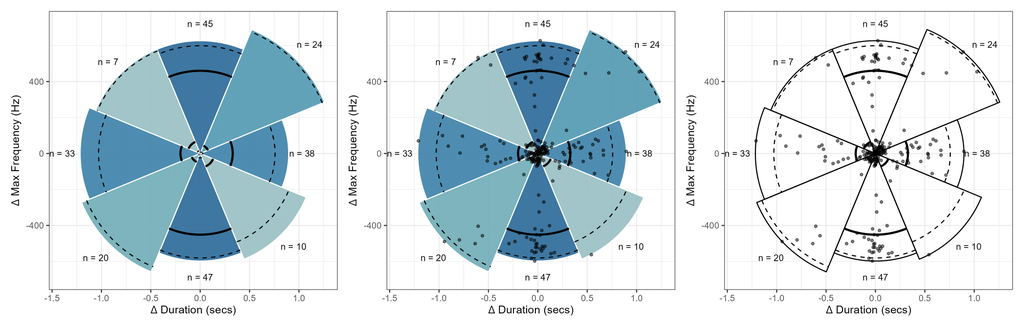

Conceptually, these are the trickier plots to describe and potentially more open to criticism. IMO they are aesthetically very pleasing and information is conveyed effectively but subject to potential misinterpretation if some elements are not plotted.

Take the plot on the left as an example. Without visualizing where the points lie, the viewer may easily be tempted, from the left-up diagonal slice, to interpolate that calls with delta duration of -0.75 secs and delta frequency of 200 Hz are plausible. Plotting the points (middle plot) shows that’s not the case - the length of the slice, and therefore the area of the slice is being pushed by a couple of points on the opposite side of the slice. Sure, the label displaying a small number of points might caution the user to be careful with strong assumptions, but still the risk of misinterpretation is non-negligible.

The choice ended up falling to the middle plot as points might help mitigate the interpolation issue. Having colored slices was thought to be a good visual aid (and prettier), and adding the “n” labels provide total clarity of number of observations comprised in each slice.

#### Absolute change

Displaying change between consecutive calls in terms of absolute differences.

Some further considerations:

- Due to the very different range of call duration between the two subjects, the color of the points encode the subject
- **Important Note**: The axes scales of each plot is determined by their inherent data. So the slicing-up of the plotting region and associated grouping of points is specific to the spread of the plotted data.

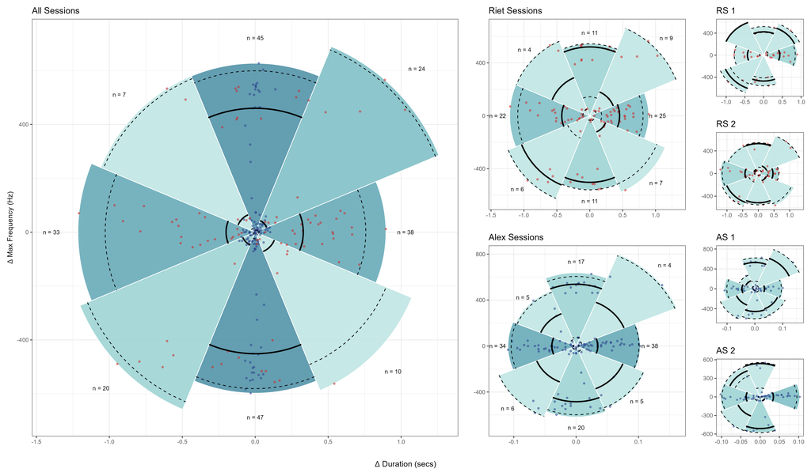

#### Percentage change

Displaying percentage change between consecutive calls.

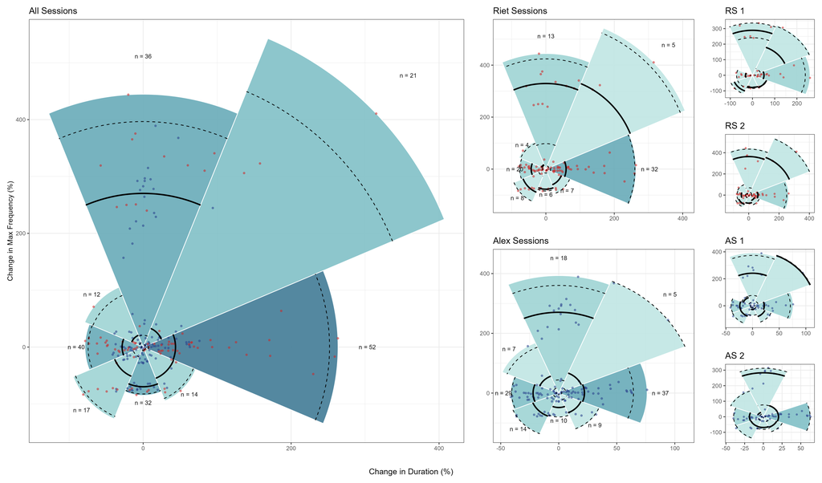

### “Rays” plots

These were built to address the concerns raised with the “Pizza” plots. Here lollipop-style rays with origin at [0, 0] (i.e. no changes) are used to express magnitude of changes.

Slice-shaped panes with colors encoding cardinal directions are provided to describe concomitant changes of the two variables between consecutive calls. For example, rays sitting on the dark blue slice express positive changes occurring predominantly on the variable mapped by the x-axis.

#### Absolute change

Displaying absolute change between consecutive calls.

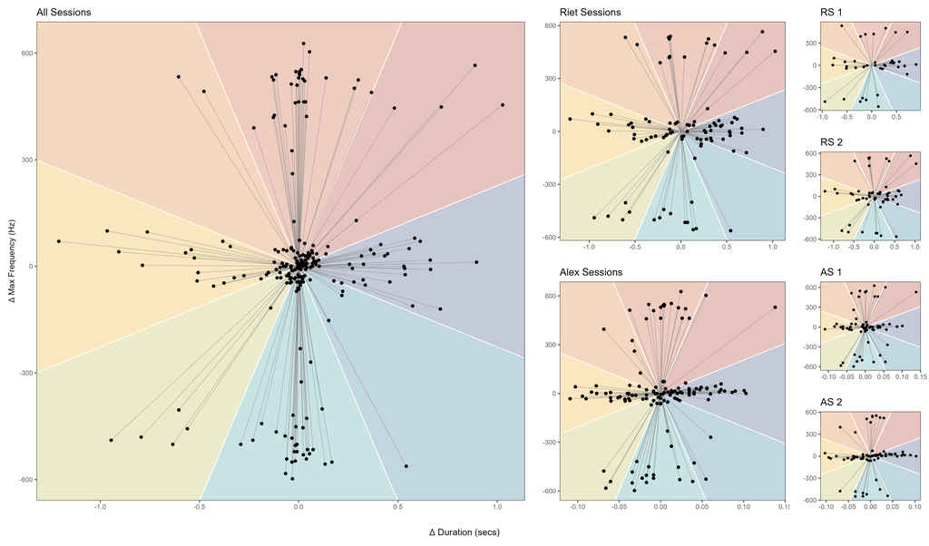

#### Percentage change

Displaying percentage change between consecutive calls.

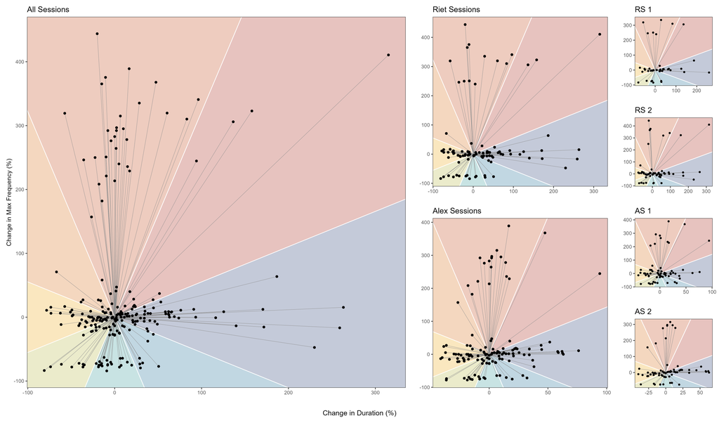